# Time Series Forecasting with Prophet

Coursework 1 – CO2 Time Series Analysis

Christina Gjoni

Spring term 2025

# 🔮 Introduction: Forecasting our Future with Prophet

Every day, we make predictions on what to wear (I can definitely relate!) based on the weather. What if we could **predict real-world trends** with data? Which is what we will delve into!

### **Objectives of This Report 📌**

✔️ **Get a sense of CO2 levels over time**

✔️ **Use Prophet to forecast future values**

✔️ **Graph trends**

✔️ **Draw conclusions about long-term trends**

### 1.1 Let’s get our data ready! 📊

Before we are able to begin predicting, we must **correctly format our data for use in Prophet.** The default **CO2 dataset** available in R provides us with monthly observations from **1959 onward.** We will **change it to a form that can be interpreted by Prophet.**

```r
# Load the required libraries
library(zoo)
# Rearrange built-in CO2 dataset to a Prophet-acceptable form
co2_df <- data.frame(
ds = zoo::as.yearmon(time(co2)), # Reshape time into Year-Month form
y <- as.numeric(co2) # Convert values to numeric
)
# Print the first few rows of the dataset
head(co2_df)
```

```
##         ds y....as.numeric.co2.
## 1 Jan 1959               315.42
## 2 Feb 1959               316.31
## 3 Mar 1959               316.50
## 4 Apr 1959               317.56
## 5 May 1959               318.13
## 6 Jun 1959               318.00
```

[output not shown]

[output not shown]

[output not shown]

### 1.2 Now lets train The Forecast Model🧮

Now that our dataset is correctly formatted, we can train the forecasting model. 👉 What the code does: ✅ Loads the prophet package ✅ Trains the Prophet model using co2_df ✅ Generates a future dataframe (8 months ahead) for predictions ✅ Prints out future time periods to confirm structure

```r
# Load required libraries
library(zoo)
library(prophet)
# Convert CO2 dataset into a Prophet-compatible format
co2_df <- data.frame(
  ds = zoo::as.yearmon(time(co2)),  # Convert time to Year-Month format
  y = as.numeric(co2)  # Convert values to numeric
)

# Correct column names
colnames(co2_df) <- c("ds", "y")

# Print structure
str(co2_df)
```

```
## 'data.frame':    468 obs. of  2 variables:
##  $ ds: 'yearmon' num  Jan 1959 Feb 1959 Mar 1959 Apr 1959 ...
##  $ y : num  315 316 316 318 318 ...
```

```r
# Print first few rows
head(co2_df)
```

```
##         ds      y
## 1 Jan 1959 315.42
## 2 Feb 1959 316.31
## 3 Mar 1959 316.50
## 4 Apr 1959 317.56
## 5 May 1959 318.13
## 6 Jun 1959 318.00
```

```r
# Train the Prophet model
m <- prophet(co2_df)
```

```
## Disabling weekly seasonality. Run prophet with weekly.seasonality=TRUE to override this.
```

```
## Disabling daily seasonality. Run prophet with daily.seasonality=TRUE to override this.
```

```r
# Create a dataframe for future predictions (8 months ahead)
future <- make_future_dataframe(m, periods = 8, freq = "month")

# Display the first few rows of future dates
head(future)
```

```
##           ds
## 1 1959-01-01
## 2 1959-02-01
## 3 1959-03-01
## 4 1959-04-01
## 5 1959-05-01
## 6 1959-06-01
```

### 1.3 Let’s Visualise the Forecast!📈

Now that we have been able to train our Prophet model, let’s get to visualizing the predicted CO2 levels! This part will make plots to enable us to observe the patterns and trends the model is forecasting.✨

```r
# Load required libraries
library(zoo)
library(prophet)

# Convert CO2 dataset into a Prophet-compatible format
co2_df <- data.frame(
  ds = zoo::as.yearmon(time(co2)),  # Convert time to Year-Month format
  y = as.numeric(co2)  # Convert values to numeric
)

# Correct column names
colnames(co2_df) <- c("ds", "y")

# Train the Prophet model
model <- prophet(co2_df)
```

```
## Disabling weekly seasonality. Run prophet with weekly.seasonality=TRUE to override this.
```

```
## Disabling daily seasonality. Run prophet with daily.seasonality=TRUE to override this.
```

```r
# Create a dataframe for future predictions (8 months ahead)
future <- make_future_dataframe(model, periods = 8, freq = "month")

# Check if future dataframe has data
head(future)
```

```
##           ds
## 1 1959-01-01
## 2 1959-02-01
## 3 1959-03-01
## 4 1959-04-01
## 5 1959-05-01
## 6 1959-06-01
```

```r
# Generate predictions
forecast <- predict(model, future)

# Check if forecast was generated
head(forecast)
```

```
##           ds    trend additive_terms additive_terms_lower additive_terms_upper
## 1 1959-01-01 315.3537    -0.07753751          -0.07753751          -0.07753751
## 2 1959-02-01 315.4387     0.59487739           0.59487739           0.59487739
## 3 1959-03-01 315.5155     1.23263039           1.23263039           1.23263039
## 4 1959-04-01 315.6005     2.46038945           2.46038945           2.46038945
## 5 1959-05-01 315.6828     3.02022342           3.02022342           3.02022342
## 6 1959-06-01 315.7678     2.35150786           2.35150786           2.35150786
##        yearly yearly_lower yearly_upper multiplicative_terms
## 1 -0.07753751  -0.07753751  -0.07753751                    0
## 2  0.59487739   0.59487739   0.59487739                    0
## 3  1.23263039   1.23263039   1.23263039                    0
## 4  2.46038945   2.46038945   2.46038945                    0
## 5  3.02022342   3.02022342   3.02022342                    0
## 6  2.35150786   2.35150786   2.35150786                    0
##   multiplicative_terms_lower multiplicative_terms_upper yhat_lower yhat_upper
## 1                          0                          0   314.8326   315.7377
## 2                          0                          0   315.5623   316.4733
## 3                          0                          0   316.2937   317.2107
## 4                          0                          0   317.5735   318.5632
## 5                          0                          0   318.2447   319.1261
## 6                          0                          0   317.6129   318.6175
##   trend_lower trend_upper     yhat
## 1    315.3537    315.3537 315.2762
## 2    315.4387    315.4387 316.0336
## 3    315.5155    315.5155 316.7481
## 4    315.6005    315.6005 318.0609
## 5    315.6828    315.6828 318.7030
## 6    315.7678    315.7678 318.1193
```

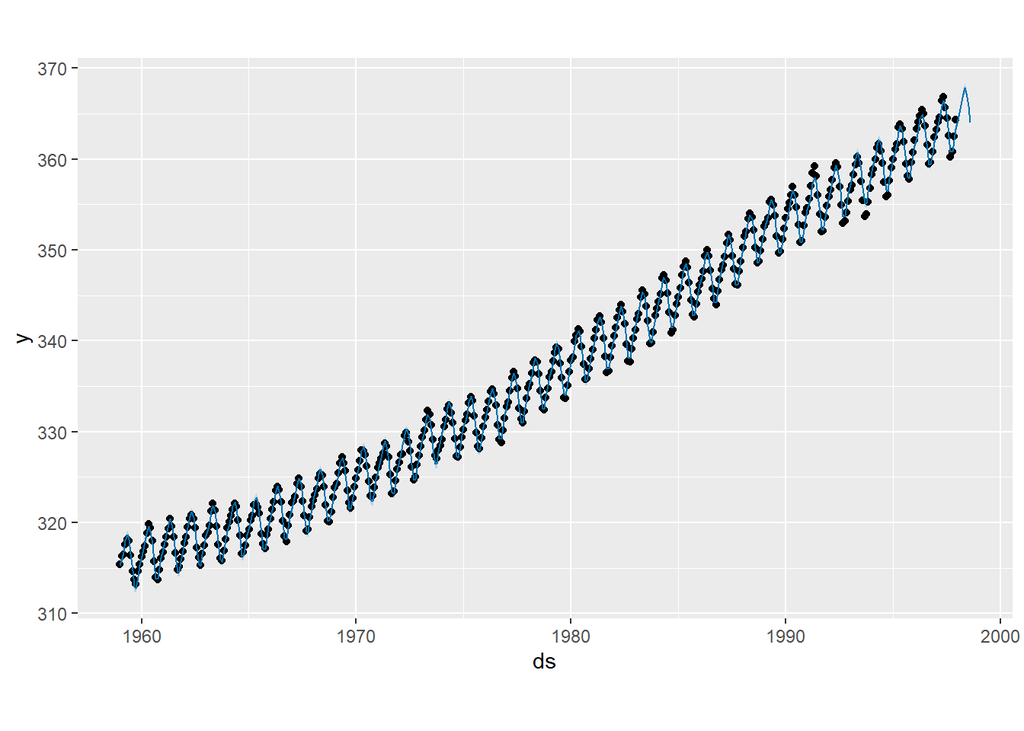

```r
# Plot the forecast
plot(model, forecast)
```

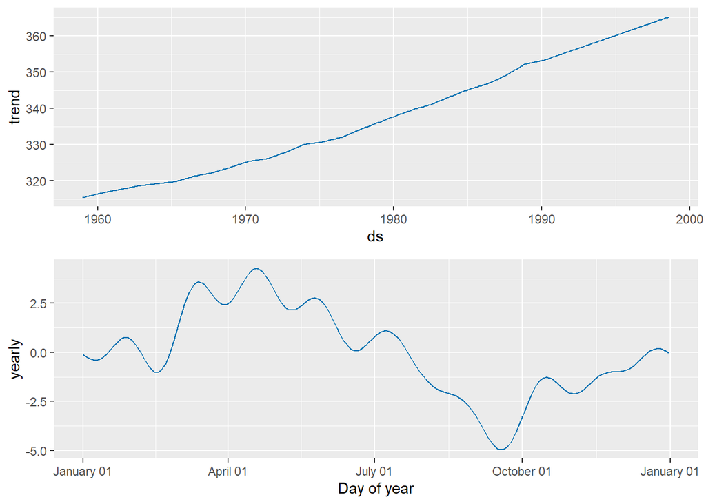

```r
# Visualise forecast components (trend, seasonality)
prophet_plot_components(model, forecast)
```

### 1.4 Analyse the Forecast! 📌

✔️ The cumulative CO2 concentrations are increasing, showing a trend of increase with time.

✔️ The confidence intervals (yhat_lower and yhat_upper) indicate potential variations in forecasts, i.e., there is some uncertainty in the future predictions of the model.

✔️ There can be seasonality, where CO2 can increase and decrease in a periodic manner due to annual trends.

[output not shown]

```
##             ds     yhat yhat_lower yhat_upper
## 471 1998-03-01 365.9365   365.5178   366.4359
## 472 1998-04-01 367.2233   366.7363   367.7061
## 473 1998-05-01 367.8519   367.3865   368.3541
## 474 1998-06-01 367.3103   366.8094   367.7920
## 475 1998-07-01 365.8836   365.4128   366.3591
## 476 1998-08-01 363.9603   363.4451   364.4850
```

# The Conclusion 🚀

**Key Takeaways:**

✅ Steady Increase in CO₂ Levels Our forecast reinforces what has been observed for a long time by climate scientists—CO₂ level is increasing steadily over the years. This is corroborated by real observations from NASA and NOAA, highlighting the gravity of climate observation.

✅ Seasonal Trends & Annual Variations Prophet was capable of detecting seasonal variations in CO₂ levels, which could be explained by natural cycles in nature, such as absorption by plants during certain times of the year and increased emissions during winter.

# References from NASA 🌍

It’s not just numbers, it’s a direct reflection of how our planet is changing. With data science and forecasting models like Prophet, we can use data to support climate change efforts, making data-driven decisions that help mitigate risks, drive solutions, and inform meaningful action. If data can make us predict the future, maybe we can change it.❤️

Website: https://climate.nasa.gov/vital-signs/carbon-dioxide/ NASA measures CO₂ concentration and climate patterns from satellite data. It provides very pleasant visualisations and information about CO₂ trends in the long-run.

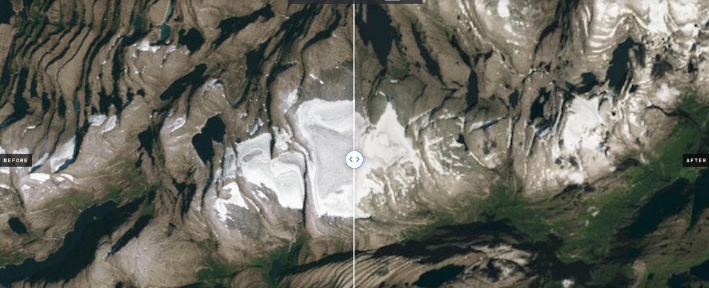